# p8130_hw6_rw2844

Renjie Wei

11/30/2020

# Problem 1

1. Create a correlation matrix

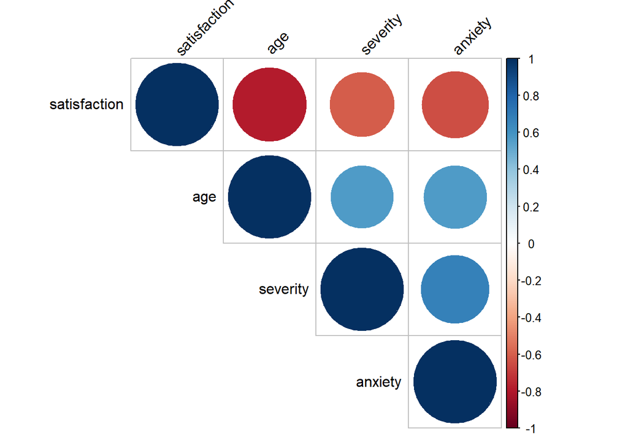

It seems that each predictor has a negative correlation with the outcome of interest.

2. Fit a multiple regression model.

Let’s set up the test hypotheses:

$H_0~:~\beta_i = 0,~i = 1,2,3$

$H_1 : at~least~one~of~the~coefficient~is~not~equal~to~0$

And our model to be test is:
$$Model_{test}:~Statisfaction=158.49 -1.14 age-0.44 severity-13.47 anxiety$$

We can test this model against the model only with intercept:

$$Model_{null}:~Statisfaction=61.57$$

And we do the ANOVA test:

The F statistic is calculated by:
$$F_{stat} = \frac{MSR}{MSE} \sim F_{p,~n-p-1},~where~p=3,~n=46$$

```
## Analysis of Variance Table
##
## Model 1: satisfaction ~ 1
## Model 2: satisfaction ~ age + severity + anxiety
##   Res.Df   RSS Df Sum of Sq    F  Pr(>F)
## 1     45 13369
## 2     42  4249  3      9120 30.1 1.5e-10 ***
## ---
## Signif. codes:  0 '***' 0.001 '**' 0.01 '*' 0.05 '.' 0.1 ' ' 1
```

**Decision Rules:** $Reject ~ H_0 ~ if ~ F_{stat}>F_{1-\alpha;~p,~n-p-1}$

In our situation, $F_{stat} = 30.1>F_{0.95;~3,~42}=2.827$

So, we reject the null hypothesis with 95% confidence and conclude that at least one coefficient is not equal to zero.

3. Show the regression results for all estimated slope coefficients with 95% CIs.

| term | estimate | 2.5 % | 97.5 % |
| --- | --- | --- | --- |
| (Intercept) | 158.491 | 121.91 | 195.071 |
| age | -1.142 | -1.57 | -0.708 |
| severity | -0.442 | -1.44 | 0.551 |
| anxiety | -13.470 | -27.80 | 0.858 |

**Interpretation:**

The 95% CI for severity of illness is $(-1.435,~0.551)$, that means at 95% confidence level, the mean change of patient satisfaction given all the same except for severity of illness per unit is between $(-1.435,~0.551)$, noticing that 0 is in this interval.

4. Obtain an interval estimate for a new patient’s satisfaction with Age=35, Severity=42, and Anxiety=2.1.

The 95% PI for this new patient is :

| lwr | upr |
| --- | --- |
| 50.1 | 93.3 |

**Interpretation:**

This means at 95% confidence level, the true estimate of patient satisfaction is between $(50.062, 93.304)$.

1. Test whether ‘anxiety level’ can be dropped from the regression model, given the other two covariates are retained.

First, we set up the hypotheses:

$H_0~:~\beta_{anxiety} = 0$

$H_1~:~\beta_{anxiety} \ne 0$

And we conduct the ANOVA test:

$$F_{stat} = \frac{MSR(X3|X1X2)}{MSE(X1X2X3)} \sim F_{df_L - df_S,df_L},~where~df_L =43 ,~df_S =42$$

```
## Analysis of Variance Table
##
## Model 1: satisfaction ~ (age + severity + anxiety) - anxiety
## Model 2: satisfaction ~ age + severity + anxiety
##   Res.Df  RSS Df Sum of Sq   F Pr(>F)
## 1     43 4613
## 2     42 4249  1       364 3.6  0.065 .
## ---
## Signif. codes:  0 '***' 0.001 '**' 0.01 '*' 0.05 '.' 0.1 ' ' 1
```

**Decision Rules:** $Reject ~ H_0 ~ if ~ F_{stat}>F_{1-\alpha;df_L - df_S,df_L}$

In our situation, $F_{stat} = 3.6<F_{0.95;~1,~42}=4.073$

So, we cannot reject the null hypothesis with 95% confidence and conclude that ‘anxiety level’ can be dropped from the regression model.

2. How are R2/R2-adjusted impacted

| Model | R_square | Adjusted_R_square |
| --- | --- | --- |
| With Anxiety | 0.682 | 0.659 |
| Without Anxiety | 0.655 | 0.639 |

We can see that the R square and Adjusted R square are higher in model with anxiety level.

# Problem 2

1. Crude association between BMI and serum estradiol
1. Scatter plot with regression line.

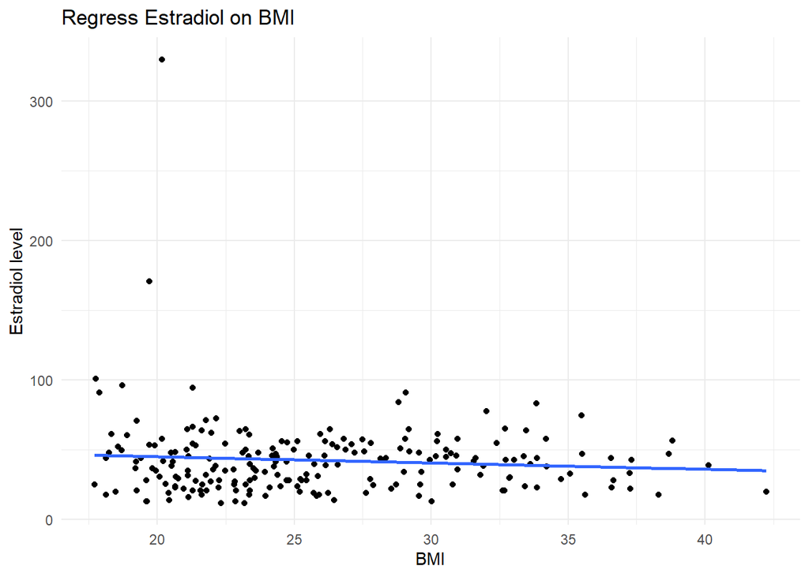

**Comments:**

As the plot shown above, the regression line has a very small slope, and the slope is negative. And there are some outliers when BMI is low.

2. Regression output

| term | estimate | std.error | statistic | p.value |
| --- | --- | --- | --- | --- |
| (Intercept) | 54.310 | 9.51 | 5.71 | 0.00 |
| bmi | -0.453 | 0.36 | -1.26 | 0.21 |

**Comments:**

The coefficient of BMI is -0.453, and the p-value is 0.21. There is little evidence showing a strong relation ship between BMI and Estradiol level.

2. Relationship between BMI and serum estradiol change after controlling for all the other risk factors

| term | estimate | std.error | statistic | p.value |
| --- | --- | --- | --- | --- |
| (Intercept) | 26.157 | 13.072 | 2.001 | 0.047 |
| ethnicCaucasian | 16.058 | 4.449 | 3.609 | 0.000 |
| entage | 0.518 | 0.359 | 1.444 | 0.150 |
| numchild | -0.491 | 1.244 | -0.394 | 0.694 |
| agemenar | 0.107 | 0.169 | 0.635 | 0.526 |
| bmi | -0.107 | 0.370 | -0.288 | 0.774 |

**Comments:**

The coefficient of BMI after controlling for all the other risk factors changed from -0.453 to -0.107, and the p-value changed from 0.21 to 0.774 The relationship between BMI and Estradiol level seems to be more insignificant after controlling.

The p-value of `entage`, `nunchild`,`agemenar` and `bmi` are relatively high and there coefficient is small in magnitude, which implies there might not be a strong relationship between estradiol level. However, the p-value of `ethnicCaucasian` is small, and its coefficient is large in magnitude, there might be a relationship between ethnic and estradiol level.

3. Focus on BMI, ethnic and estradiol level
1. Graphical displays and numerical summaries

First I will draw a scatter plot about Estradiol level vs BMI by Ethnic:

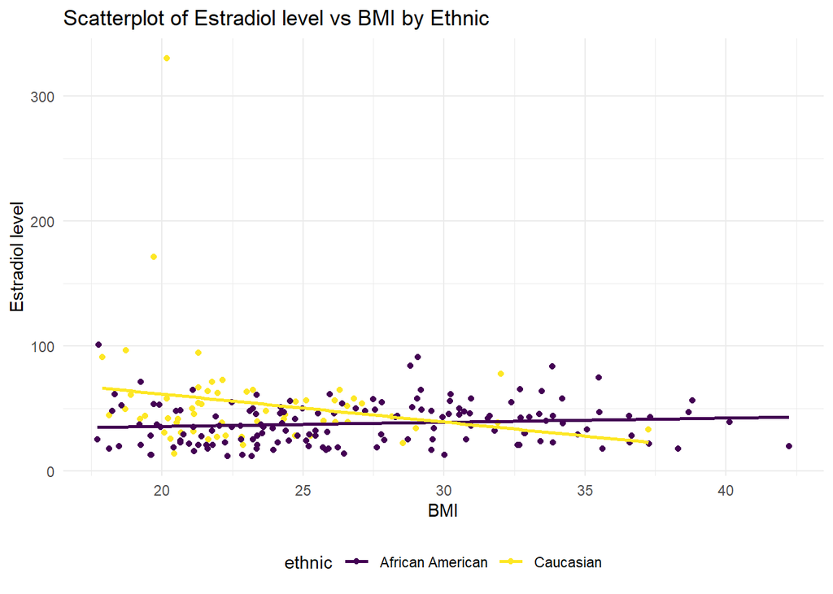

From the plots, we can see a cross over two regression line, that is a indication of interactions between `BMI` and `ethnic`.

Let’s build a model with this interaction and see if it is significant.

```
##
## Call:
## lm(formula = estradl ~ bmi * ethnic, data = estradl_df)
##
## Residuals:
##    Min     1Q Median     3Q    Max
## -46.60 -15.21  -3.38  10.12 268.79
##
## Coefficients:
##                     Estimate Std. Error t value Pr(>|t|)
## (Intercept)           29.075     10.757    2.70   0.0074 **
## bmi                    0.333      0.392    0.85   0.3976
## ethnicCaucasian       77.210     24.784    3.12   0.0021 **
## bmi:ethnicCaucasian   -2.568      1.029   -2.50   0.0133 *
## ---
## Signif. codes:  0 '***' 0.001 '**' 0.01 '*' 0.05 '.' 0.1 ' ' 1
##
## Residual standard error: 27 on 206 degrees of freedom
## Multiple R-squared:  0.0963, Adjusted R-squared:  0.0831
## F-statistic: 7.32 on 3 and 206 DF,  p-value: 0.00011
```

From the summary of the model, we can see that the interaction is significant. With p-value 0.0133.

2. Additional steps

Since there is a significant interaction, we need to do stratified analysis.

```r
caucasian_df =
  estradl_df %>%
  filter(ethnic == "Caucasian")

aamerican_df =
  estradl_df %>%
  filter(ethnic == "African American")

strat_reg_cau = lm(estradl ~ bmi, data = caucasian_df)
strat_reg_aam = lm(estradl ~ bmi, data = aamerican_df)
```

So in Caucasian, a negative, relatively large in magnitude association b/w BMI and estradiol level

```
##
## Call:
## lm(formula = estradl ~ bmi, data = caucasian_df)
##
## Residuals:
##    Min     1Q Median     3Q    Max
## -46.60 -20.79  -6.80   8.14 268.79
##
## Coefficients:
##             Estimate Std. Error t value Pr(>|t|)
## (Intercept)   106.29      35.71    2.98   0.0043 **
## bmi            -2.24       1.52   -1.47   0.1470
## ---
## Signif. codes:  0 '***' 0.001 '**' 0.01 '*' 0.05 '.' 0.1 ' ' 1
##
## Residual standard error: 43.2 on 57 degrees of freedom
## Multiple R-squared:  0.0365, Adjusted R-squared:  0.0196
## F-statistic: 2.16 on 1 and 57 DF,  p-value: 0.147
```

And in African American, a positive association b/w BMI and estradiol level.

```
##
## Call:
## lm(formula = estradl ~ bmi, data = aamerican_df)
##
## Residuals:
##    Min     1Q Median     3Q    Max
##  -26.1  -14.0   -1.1   11.0   66.0
##
## Coefficients:
##             Estimate Std. Error t value Pr(>|t|)
## (Intercept)   29.075      6.839    4.25  3.7e-05 ***
## bmi            0.333      0.250    1.33     0.18
## ---
## Signif. codes:  0 '***' 0.001 '**' 0.01 '*' 0.05 '.' 0.1 ' ' 1
##
## Residual standard error: 17.2 on 149 degrees of freedom
## Multiple R-squared:  0.0118, Adjusted R-squared:  0.00516
## F-statistic: 1.78 on 1 and 149 DF,  p-value: 0.184
```

However, both associations are not statistically significant.

And to see if Ethnic is a confounder of BMI, it need to meet 3 conditions

Condition 1) Associated with the outcome:

```
##
## Call:
## lm(formula = estradl ~ ethnic, data = .)
##
## Residuals:
##    Min     1Q Median     3Q    Max
##  -40.5  -15.1   -3.5   10.0  275.6
##
## Coefficients:
##                 Estimate Std. Error t value Pr(>|t|)
## (Intercept)        38.00       2.22   17.10  < 2e-16 ***
## ethnicCaucasian    16.45       4.19    3.92  0.00012 ***
## ---
## Signif. codes:  0 '***' 0.001 '**' 0.01 '*' 0.05 '.' 0.1 ' ' 1
##
## Residual standard error: 27.3 on 208 degrees of freedom
## Multiple R-squared:  0.0689, Adjusted R-squared:  0.0644
## F-statistic: 15.4 on 1 and 208 DF,  p-value: 0.000119
```

Yes, ethnic is associated with estradiol level with a very small p-value.

Condition 2) Associated with the exposure:

```
##
## Call:
## lm(formula = bmi ~ ethnic, data = .)
##
## Residuals:
##    Min     1Q Median     3Q    Max
##  -9.11  -3.60  -1.06   3.39  15.41
##
## Coefficients:
##                 Estimate Std. Error t value Pr(>|t|)
## (Intercept)       26.832      0.420   63.82  < 2e-16 ***
## ethnicCaucasian   -3.641      0.793   -4.59  7.7e-06 ***
## ---
## Signif. codes:  0 '***' 0.001 '**' 0.01 '*' 0.05 '.' 0.1 ' ' 1
##
## Residual standard error: 5.17 on 208 degrees of freedom
## Multiple R-squared:  0.092,  Adjusted R-squared:  0.0876
## F-statistic: 21.1 on 1 and 208 DF,  p-value: 7.65e-06
```

Yes, ethnic is associated with BMI with a extreme small p-value.

Condition 3) Not on the causal pathway b/w exposure and outcome, which is obvious.

| term | estimate | std.error | statistic | p.value |
| --- | --- | --- | --- | --- |
| (Intercept) | 54.310 | 9.51 | 5.71 | 0.00 |
| bmi | -0.453 | 0.36 | -1.26 | 0.21 |

| term | estimate | std.error | statistic | p.value |
| --- | --- | --- | --- | --- |
| (Intercept) | 39.105 | 10.104 | 3.870 | 0.000 |
| bmi | -0.041 | 0.367 | -0.112 | 0.911 |
| ethnicCaucasian | 16.297 | 4.410 | 3.696 | 0.000 |

And by comparing model controlling `ethnic` and not, we can see that the BMI coefficient reduced from -0.453 in SLR to -0.041 in MLR after adjusting for `ethnic` (~90% reduction). We can conclude that `ethnic` confounds the relationship b/w `BMI` and `estradiol level`.

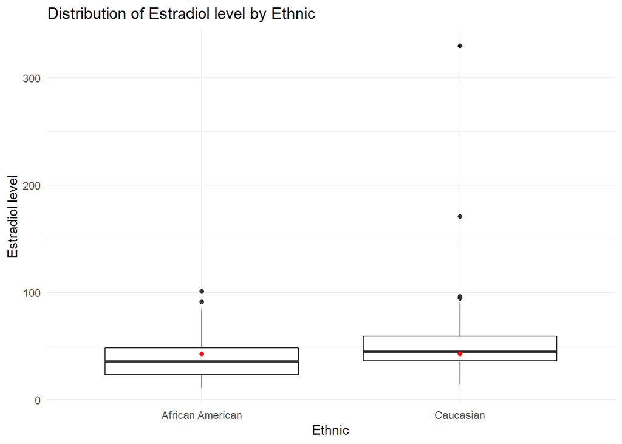